# Proyek Analisis Data: Perjalanan Sepeda Cyclistic Tahun 2023

## STEP 3: Proses (Process)

Data yang telah digabung akan diproses dengan melakukan pembersihan data.

### **Periksa kolom pada dataframe terlebih dahulu**

```r
glimpse(all_data)         # melihat seluruh data secara sekilas
```

```
## Rows: 3,909,564
## Columns: 13
## $ ride_id            <chr> "C1D650626C8C899A", "EECD38BDB25BFCB0", "F4A9CE7806…
## $ rideable_type      <chr> "electric_bike", "electric_bike", "electric_bike", …
## $ started_at         <chr> "2024-01-12 15:30:27", "2024-01-08 15:45:46", "2024…
## $ ended_at           <chr> "2024-01-12 15:37:59", "2024-01-08 15:52:59", "2024…
## $ start_station_name <chr> "Wells St & Elm St", "Wells St & Elm St", "Wells St…
## $ start_station_id   <chr> "KA1504000135", "KA1504000135", "KA1504000135", "TA…
## $ end_station_name   <chr> "Kingsbury St & Kinzie St", "Kingsbury St & Kinzie …
## $ end_station_id     <chr> "KA1503000043", "KA1503000043", "KA1503000043", "13…
## $ start_lat          <dbl> 41.90327, 41.90294, 41.90295, 41.88430, 41.94880, 4…
## $ start_lng          <dbl> -87.63474, -87.63444, -87.63447, -87.63396, -87.675…
## $ end_lat            <dbl> 41.88918, 41.88918, 41.88918, 41.92182, 41.88918, 4…
## $ end_lng            <dbl> -87.63851, -87.63851, -87.63851, -87.64414, -87.638…
## $ member_casual      <chr> "member", "member", "member", "member", "member", "…
```

```r
summary(all_data)         # melihat statistik data
```

```
##    ride_id          rideable_type       started_at          ended_at
##  Length:3909564     Length:3909564     Length:3909564     Length:3909564
##  Class :character   Class :character   Class :character   Class :character
##  Mode  :character   Mode  :character   Mode  :character   Mode  :character
##
##
##
##
##  start_station_name start_station_id   end_station_name   end_station_id
##  Length:3909564     Length:3909564     Length:3909564     Length:3909564
##  Class :character   Class :character   Class :character   Class :character
##  Mode  :character   Mode  :character   Mode  :character   Mode  :character
##
##
##
##
##    start_lat       start_lng         end_lat         end_lng
##  Min.   :41.64   Min.   :-87.90   Min.   :16.06   Min.   :-144.05
##  1st Qu.:41.88   1st Qu.:-87.66   1st Qu.:41.88   1st Qu.: -87.66
##  Median :41.90   Median :-87.64   Median :41.90   Median : -87.64
##  Mean   :41.90   Mean   :-87.65   Mean   :41.90   Mean   : -87.65
##  3rd Qu.:41.93   3rd Qu.:-87.63   3rd Qu.:41.93   3rd Qu.: -87.63
##  Max.   :42.07   Max.   :-87.52   Max.   :87.96   Max.   : -79.02
##                                   NA's   :5507    NA's   :5507
##  member_casual
##  Length:3909564
##  Class :character
##  Mode  :character
##
##
##
##
```

```r
colSums(is.na(all_data))  # melihat data null di setiap kolom
```

```
##            ride_id      rideable_type         started_at           ended_at
##                  0                  0                  0                  0
## start_station_name   start_station_id   end_station_name     end_station_id
##              19165              19165              20749              20749
##          start_lat          start_lng            end_lat            end_lng
##                  0                  0               5507               5507
##      member_casual
##                  0
```

```r
## Mengecek kolom rideable_type
table(all_data$rideable_type)
```

```
##
##  classic_bike electric_bike
##       1921812       1987752
```

```r
## Mengecek kolom member_casual untuk memastikan hanya casual dan member
table(all_data$member_casual)
```

```
##
##  casual  member
## 1456954 2452610
```

### **Menambahkan kolom untuk membantu analisis data**

Mengubah kolom started_at dan ended_at ke tipe datetime agar dapat dilakukan kalkulasi.

```r
all_data <- all_data %>%
  mutate(
    started_at = as_datetime(started_at),
    ended_at = as_datetime(ended_at)
  )
```

Membuat kolom date(yyyy-mm-dd), day_of_week (hari), day (tanggal), month (bulan), dan year (tahun)

```r
all_data$date <- format(as.Date(all_data$started_at))
all_data$day_of_week <- format(as.Date(all_data$started_at), "%A") #sunday, Monday, etc.
all_data$day <- format(as.Date(all_data$started_at), "%d")
all_data$month <- format(as.Date(all_data$started_at), "%m")
all_data$year <- format(as.Date(all_data$started_at), "%Y")
```

Membuat kolom ride_length dengan melakukan kalkulasi kolom started_at dengan ended_at untuk memuat lama waktu perjalanan (menit)

```r
all_data$ride_length <- as.numeric(difftime(all_data$ended_at, all_data$started_at, units = "mins"))
```

## STEP 4 : Analisis (Analyze)

Melakukan analisis deskriptif, metode analisis statistik yang digunakan untuk menggambarkan atau merangkum karakteristik utama dari suatu kumpulan data.

### **Menganalisis kolom ride_length**

```r
summary_ride <- all_data %>%
  summarise(
    mean = mean(ride_length),
    median = median(ride_length),
    max = max(ride_length),
    min = min(ride_length)
  )
summary_ride
```

```
## # A tibble: 1 × 4
##    mean median   max    min
##   <dbl>  <dbl> <dbl>  <dbl>
## 1  18.3   10.1 1560. -2748.
```

Filter ride_length yang kurang dari 0.

```r
all_data <- all_data %>%
  filter(ride_length >= 0)
min(all_data$ride_length)
```

```
## [1] 0
```

### **Menganalisis untuk mengetahui perbandingan banyak pengguna dan lama perjalanan**

```r
summary_user <- all_data %>%
  group_by(member_casual) %>%
  summarise(count = n(), # banyak pengguna
            mean_ride_length = mean(ride_length)) %>%
  mutate(percentage = count / sum(count) * 100) # presentase pengguna
summary_user
```

```
## # A tibble: 2 × 4
##   member_casual   count mean_ride_length percentage
##   <chr>           <int>            <dbl>      <dbl>
## 1 casual        1456882             26.8       37.3
## 2 member        2452498             13.3       62.7
```

### **Mengelompokkan tipe sepeda yang digunakan pengendara**

```r
summary_rideable_type <- all_data %>%
  group_by(member_casual, rideable_type) %>%
  summarize(count = n(),
            mean_ride_length = mean(ride_length),
            .groups = "keep",)
summary_rideable_type
```

```
## # A tibble: 4 × 4
## # Groups:   member_casual, rideable_type [4]
##   member_casual rideable_type   count mean_ride_length
##   <chr>         <chr>           <int>            <dbl>
## 1 casual        classic_bike   703417             39.4
## 2 casual        electric_bike  753465             15.1
## 3 member        classic_bike  1218393             15.2
## 4 member        electric_bike 1234105             11.4
```

### **Menganalisis untuk melihat rata-rata ride_length per hari untuk pengendara**

```r
aggregate(all_data$ride_length ~ all_data$member_casual + all_data$day_of_week, FUN = mean)
```

```
##    all_data$member_casual all_data$day_of_week all_data$ride_length
## 1                  casual               Friday             26.47728
## 2                  member               Friday             12.86404
## 3                  casual               Monday             25.77724
## 4                  member               Monday             12.70030
## 5                  casual             Saturday             29.45870
## 6                  member             Saturday             14.72597
## 7                  casual               Sunday             30.84034
## 8                  member               Sunday             14.87229
## 9                  casual             Thursday             23.73879
## 10                 member             Thursday             12.65509
## 11                 casual              Tuesday             23.32642
## 12                 member              Tuesday             12.77921
## 13                 casual            Wednesday             24.38230
## 14                 member            Wednesday             12.98875
```

```r
# Mengurutkan nama hari
all_data$day_of_week <- ordered(all_data$day_of_week, levels=c("Sunday", "Monday", "Tuesday", "Wednesday", "Thursday", "Friday", "Saturday"))

aggregate(all_data$ride_length ~ all_data$member_casual + all_data$day_of_week, FUN = mean)
```

```
##    all_data$member_casual all_data$day_of_week all_data$ride_length
## 1                  casual               Sunday             30.84034
## 2                  member               Sunday             14.87229
## 3                  casual               Monday             25.77724
## 4                  member               Monday             12.70030
## 5                  casual              Tuesday             23.32642
## 6                  member              Tuesday             12.77921
## 7                  casual            Wednesday             24.38230
## 8                  member            Wednesday             12.98875
## 9                  casual             Thursday             23.73879
## 10                 member             Thursday             12.65509
## 11                 casual               Friday             26.47728
## 12                 member               Friday             12.86404
## 13                 casual             Saturday             29.45870
## 14                 member             Saturday             14.72597
```

### **Menganalisis perjalanan berdasarkan pengguna dan hari**

```r
summary_data <- all_data %>%
  group_by(member_casual, day_of_week) %>%
  summarise(number_of_rides = n(),  #jumlah baris di setiap group
            average_duration = mean(ride_length),
            .groups = "keep") %>%
  arrange(member_casual, day_of_week)
summary_data
```

```
## # A tibble: 14 × 4
## # Groups:   member_casual, day_of_week [14]
##    member_casual day_of_week number_of_rides average_duration
##    <chr>         <ord>                 <int>            <dbl>
##  1 casual        Sunday               243030             30.8
##  2 casual        Monday               163052             25.8
##  3 casual        Tuesday              156220             23.3
##  4 casual        Wednesday            185123             24.4
##  5 casual        Thursday             178468             23.7
##  6 casual        Friday               215902             26.5
##  7 casual        Saturday             315087             29.5
##  8 member        Sunday               273790             14.9
##  9 member        Monday               344982             12.7
## 10 member        Tuesday              374574             12.8
## 11 member        Wednesday            405108             13.0
## 12 member        Thursday             379627             12.7
## 13 member        Friday               348259             12.9
## 14 member        Saturday             326158             14.7
```

## STEP 5 : Membagikan (Share)

Setelah melakukan analisis, langkah selanjutnya adalah membuat visualisasi untuk membagikan analisis sebelumnya.

### **Membuat pie chart untuk melihat jumlah perjalanan yang dilakukan pengendara**

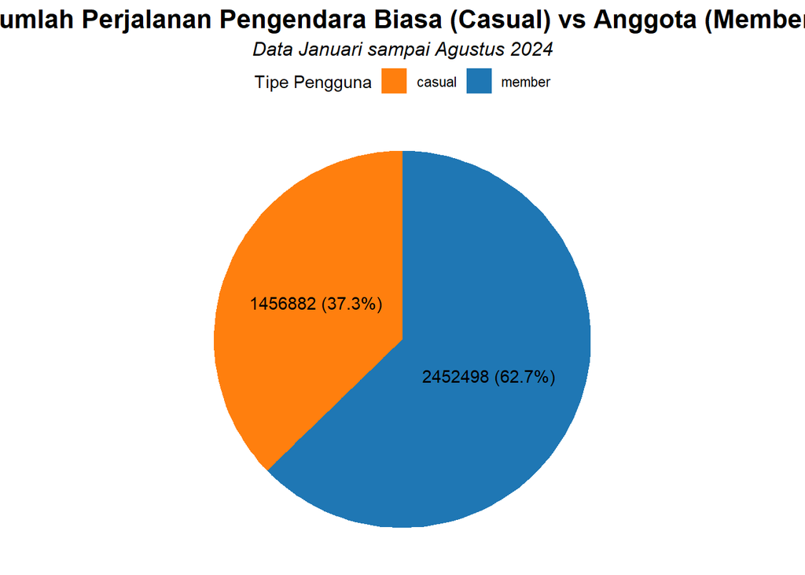

```r
summary_user %>%
  ggplot(aes(x = "", y = count, fill = member_casual)) +
  geom_bar(stat = "identity", width = 1) +
  coord_polar(theta = "y") +
  labs(title = "Jumlah Perjalanan Pengendara Biasa (Casual) vs Anggota (Member)",
       subtitle = "Data Januari sampai Agustus 2024",
       fill = "Tipe Pengguna") +
  scale_fill_manual(values = c("member" = "#1f77b4", "casual" = "#ff7f0e")) +
  theme_void() +
  theme(plot.title = element_text(hjust = 0.5, size = 16, face = "bold"),
        plot.subtitle = element_text(hjust = 0.5, size = 12, face = "italic", margin = margin(t = 5, b = 5)),
        legend.position = "top") +
  geom_text(aes(label = paste0(count, " (", round(percentage, 1), "%)")),
            position = position_stack(vjust = 0.5))
```

### **Membuat bar chart untuk rata-rata durasi perjalanan pengendara berdasarkan jenis sepeda**

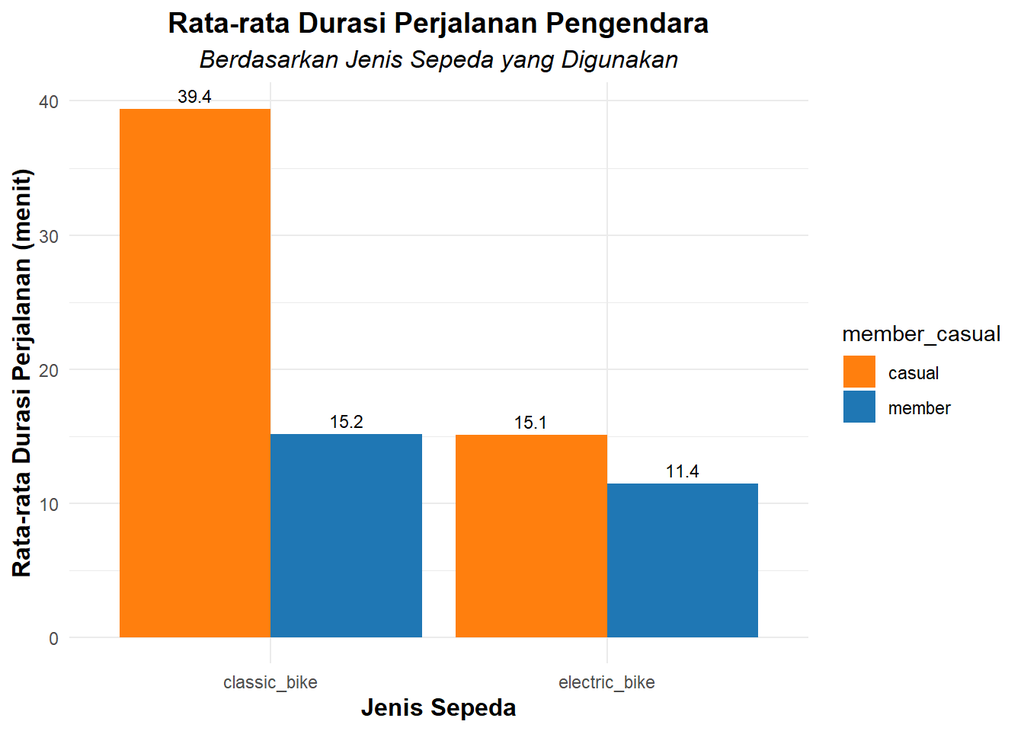

```r
summary_rideable_type %>%
  ggplot(aes(x = rideable_type, y = mean_ride_length, fill = member_casual)) +
  geom_bar(stat = "identity", position = "dodge") +
  labs(title = "Rata-rata Durasi Perjalanan Pengendara",
       subtitle = "Berdasarkan Jenis Sepeda yang Digunakan",
       x = "Jenis Sepeda",
       y = "Rata-rata Durasi Perjalanan (menit)") +
  scale_fill_manual(values = c("member" = "#1f77b4", "casual" = "#ff7f0e")) +
  theme_minimal() +
  theme(plot.title = element_text(hjust = 0.5, size = 14, face = "bold"),
        plot.subtitle = element_text(hjust = 0.5, size = 12, face = "italic"),
        axis.title.x = element_text(size = 12, face = "bold"),
        axis.title.y = element_text(size = 12, face = "bold")) +
  geom_text(aes(label = round(mean_ride_length, 1)),
            position = position_dodge(width = 0.9),
            vjust = -0.5,
            size = 3)
```

### **Membuat bar chart untuk banyak perjalanan yang dilakukan pengendara**

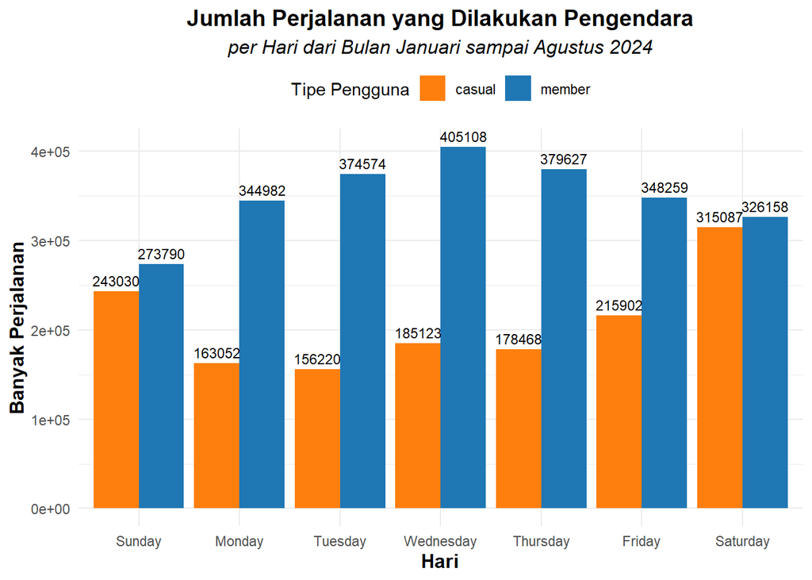

```r
summary_data  %>%
  ggplot(aes(x = day_of_week, y = number_of_rides, fill = member_casual)) +
  geom_col(position = "dodge") +
  labs(title = "Jumlah Perjalanan yang Dilakukan Pengendara",
       subtitle = "per Hari dari Bulan Januari sampai Agustus 2024",
       x = "Hari",
       y = "Banyak Perjalanan",
       fill = "Tipe Pengguna") +
  scale_fill_manual(values = c("member" = "#1f77b4", "casual" = "#ff7f0e")) +
  theme_minimal() +
  theme(plot.title = element_text(hjust = 0.5, size = 14, face = "bold"),
        plot.subtitle = element_text(hjust = 0.5, size = 12, face = "italic"),
        axis.title.x = element_text(size = 12, face = "bold"),
        axis.title.y = element_text(size = 12, face = "bold"),
        legend.position = "top") +
  geom_text(aes(label = number_of_rides),
            position = position_dodge(width = 0.9),
            vjust = -0.5,
            size = 3)
```

### **Membuat bar chart untuk rata-rata durasi perjalanan pengendara**

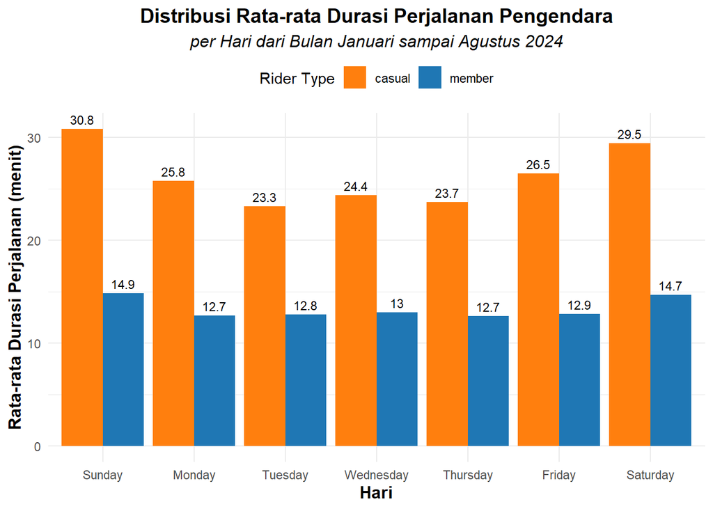

```r
summary_data %>%
  ggplot(aes(x = day_of_week, y = average_duration, fill = member_casual)) +
  geom_col(position = "dodge") +
  labs(title = "Distribusi Rata-rata Durasi Perjalanan Pengendara",
       subtitle = "per Hari dari Bulan Januari sampai Agustus 2024",
       x = "Hari",
       y = "Rata-rata Durasi Perjalanan (menit)",
       fill = "Rider Type") +
  scale_fill_manual(values = c("member" = "#1f77b4", "casual" = "#ff7f0e")) +
  theme_minimal() +
  theme(plot.title = element_text(hjust = 0.5, size = 14, face = "bold"),
        plot.subtitle = element_text(hjust = 0.5, size = 12, face = "italic"),
        axis.title.x = element_text(size = 12, face = "bold"),
        axis.title.y = element_text(size = 12, face = "bold"),
        legend.position = "top") +
  geom_text(aes(label = round(average_duration, 1)),
            position = position_dodge(width = 0.9),
            vjust = -0.5,
            size = 3)
```

## STEP 6 : Bertindak (Act)

Berdasarkan analisis, kesimpulan yang didapat adalah :

*1. Bagaimana anggota tahunan dan pengendara biasa menggunakan sepeda secara berbeda?*

Pengendara biasa lebih lama melakukan perjalanan di hari Minggu dengan rata-rata durasi 30.8 menit. Berbeda dengan pengendara biasa, pengendara anggota melakukan perjalanan dengan rata-rata durasi 14.9 menit di hari Minggu yang merupakan rata-rata dursi terlama dari hari-hari lainnya.

Jumlah perjalanan yang dilakukan oleh pengendara anggota lebih tinggi di hari Rabu (Wednesday) dengan total 405.108 perjalanan, sedangkan untuk pengendara biasa lebih tinggi di hari Sabtu dengan total 315.087 perjalanan.

*2. Apa trategi pemasaran baru untuk mengubah pengendara biasa menjadi anggota tahunan?*

- **Memberikan Penawaran Diskon untuk Pengendara Anggota (member)**, Cyclistic dapat menawarkan diskon untuk pengendara anggota yang sering melakukan perjalanan jarak jauh sehingga pengendara biasa (casual) yang biasanya mengahabiskan durasi perjalanan lebih lama bisa tertarik berlangganan menjadi member Cyclistic. Selain itu, Cyclistic juga dapat memberikan diskon tersebut saat weekend seperti hari Sabtu dan Minggu karena pengguna biasa lebih lama melakukan perjalanan di hari tersebut. Lebih spesifik lagi, penawaran diskon dapat diberikan khusus untuk jenis sepeda classic karena pengendara biasa berkendara menggunakan sepeda tersebut untuk durasi yang lebih lama.
- **Memanfaatkan media digital**, Cyclistic dapat memanfaatkan media sosial untuk membuat iklan yang berisi informasi tentang benefit ketika menjadi anggota Cyclistic. Selain itu, Cyclistic dapat membuat konten tentang pengalaman pengendara anggota selama berlangganan menjadi anggota tahunan, serta meminta testimoni dari mereka sehingga pengguna casual tertarik menjadi member Cyclistic. Cyclistic juga dapat memanfaatkan media sosial untuk mengumumkan diskon dengan design yang menarik atensi pengendara biasa untuk membaca dan berlangganan menjadi anggota tahunan.